# Visualising two ordinal variables using R

Will Ball

03/07/2020

The code outlined below demonstrates a few simple ways of visualising the relationship between two ordinal variables. Ordinal variables are ordered factors in R - a variable with a number of levels arranged in a hierarchy. For the purposes of this, we will be looking at a 5-level measure of Deprivation and a 5-level measure of Self-Rated Health.

You could present this information in a series of tables, or as a contingency table which shows the frequency distribution of the two variables in a matrix format.

Instead, it might be easier to express (or quickly assess) the relationship between the variables using one/all of these four plots:

1. Heatmap
2. Mosaic Plot
3. Proportional Stacked Bar Chart
4. River Plot

## Getting Started

#### Packages

Before we start creating plots, we need to install and load the following packages. We’re mostly using ggplot2, but also some add-ons. You should use `install.packages("pkg")` before loading them from the library.

```r
library(tidyverse)
library(ggmosaic)
library(viridis)
library(ggalluvial)
```

#### Data

We also need to create a dummy dataset to make the visualisation.

I’m creating a tibble with the following variables:

- **ID:** to identify individuals
- **group:** a subset of the population
- **health:** 5-levels, ordered from 1 = Very Good to 5 = Very Poor
- **deprivation:** 5-levels, ordered from 1 = Least Deprived to 5 = Most Deprived

Note that I’m also specifying the distribution of the levels so that they don’t come out as equally distributed (and result in a pretty boring visualisation).

```r
mockup <- as_tibble(
  list(
        ID = c(1:5000),
        group = as.factor(sample(0:1, 5000, prob = c(0.7, 0.3), replace = TRUE)),
        health = as.factor(sample(1:5,
                             5000, prob = c(0.25, 0.21, 0.10, 0.05, 0.03), replace = TRUE)),
        deprivation = as.factor(sample(1:5,
                                   5000, prob = c(0.22, 0.17, 0.14, 0.14, 0.10), replace = TRUE))
        )
      )
head(mockup)
```

```
## # A tibble: 6 x 4
##      ID group health deprivation
##   <int> <fct> <fct>  <fct>
## 1     1 0     2      4
## 2     2 0     2      1
## 3     3 1     1      5
## 4     4 0     1      4
## 5     5 1     1      2
## 6     6 0     1      1
```

## Plots

### Option 1: Heatmap

A heatmap shows the magnitude or frequency of an observation as colour in 2D. It works essentially like a contingency table but rather than showing the raw numbers, you can see the colour variation.

For comparison here’s a very simple contingency table.

```r
my_table <- mockup %>%
  group_by(deprivation, health) %>%
  tally() %>%
  spread(key = health, value = n)
print.data.frame(my_table)
```

```
##   deprivation   1   2   3   4  5
## 1           1 534 471 241 108 84
## 2           2 438 372 181  91 53
## 3           3 346 270 146  54 32
## 4           4 345 327 143  73 45
## 5           5 249 215  99  53 30
```

And here’s how we build the heatmap plot. I’ve re-oriented the x axis label and reversed the order displayed for the y axis so that it’s equivalent to the contingency table output. Which do you think is easier to understand?

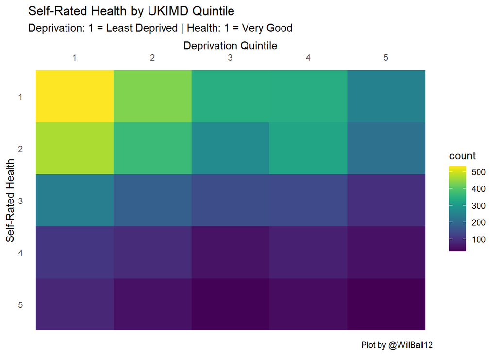

```r
ggplot(mockup, aes(deprivation, health)) +
  scale_fill_viridis() +
  geom_bin2d() +
  scale_x_discrete(name = "Deprivation Quintile",
                   position = "top") +
  scale_y_discrete(name = "Self-Rated Health",
                   limits = rev(levels(mockup$health))) +
  labs(title = "Self-Rated Health by UKIMD Quintile",
       subtitle = "Deprivation: 1 = Least Deprived | Health: 1 = Very Good",
       caption = "Plot by @WillBall12") +
  theme_minimal() +
  theme(panel.grid.major = element_blank(),
        panel.grid.minor = element_blank())
```

### Option 2: Mosaic Plot

A mosaic plot is very similar to a heatmap, except that the frequency of an observation (e.g. response is Deprivation group 1 & Health group 1) is proportional to the area of a tile, rather than by colour. Colour in this instance distinguishes the self-rated health response.

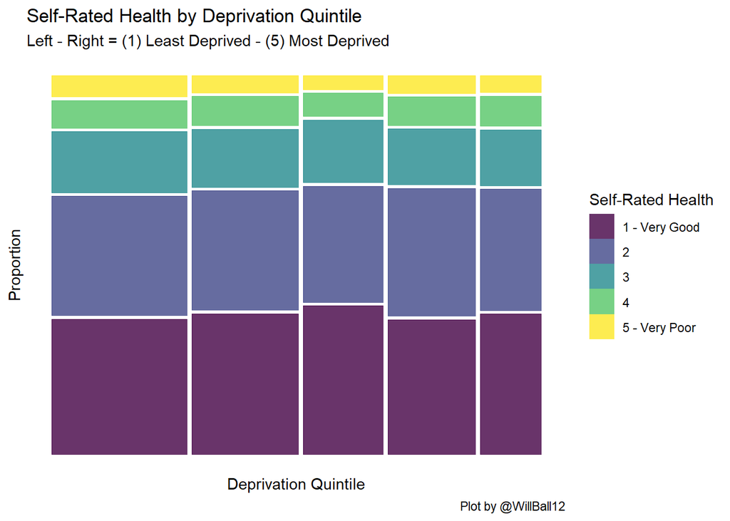

```r
ggplot(data = mockup) +
  geom_mosaic(aes(x = product(health, deprivation), fill = health),
              na.rm=TRUE) +
  labs(x = "Deprivation Quintile",
       y = "Proportion",
       title="Self-Rated Health by Deprivation Quintile",
       subtitle = "Left - Right = (1) Least Deprived - (5) Most Deprived",
       caption = "Plot by @WillBall12") +
  scale_fill_manual(values=c("#440145FF", "#404788FF", "#238A8DFF", "#55C667FF", "#FDE725FF"),
                    name="Self-Rated Health",
                    breaks=c("1", "2", "3", "4", "5"),
                    labels=c("1 - Very Good", "2", "3", "4", "5 - Very Poor")) +
  theme_minimal() +
  theme(panel.grid.major = element_blank(),
        panel.grid.minor = element_blank())
```

### Option 3: Proportional Stacked Bar Chart

This might be a more familiar and common visualisation but it does a nice job of quickly presenting how levels of a category are distributed. I think it’s preferable to providing a table of percentages.

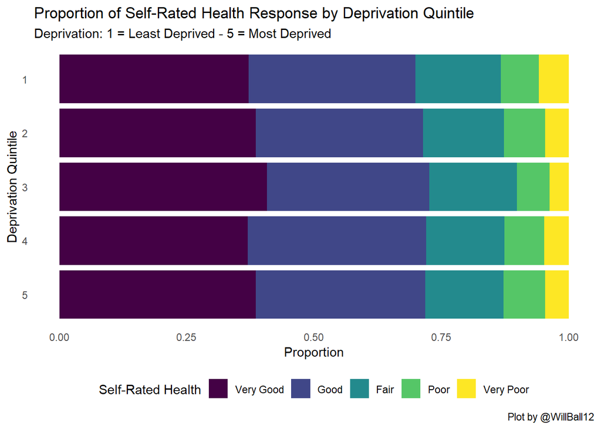

```r
ggplot(mockup,
       aes(y = reorder(deprivation, desc(deprivation)))) +
  geom_bar(aes(fill = health),
           position = position_fill(reverse = TRUE)) +
  scale_fill_manual(values=c("#440145FF", "#404788FF", "#238A8DFF", "#55C667FF", "#FDE725FF"),
                    name="Self-Rated Health",
                    breaks=c("1", "2", "3", "4", "5"),
                    labels=c("Very Good", "Good", "Fair", "Poor", "Very Poor")) +
  labs(title = "Proportion of Self-Rated Health Response by Deprivation Quintile",
       subtitle = "Deprivation: 1 = Least Deprived - 5 = Most Deprived",
       x = "Proportion",
       y = "Deprivation Quintile",
       caption = "Plot by @WillBall12") +
  theme_minimal() +
  theme(legend.position = "bottom",
        panel.grid.major = element_blank(),
        panel.grid.minor = element_blank())
```

This plot is also quite well suited to comparing these distributions on a subset. Remember the **group** variable? You can create the plot below by adding `+ facet_grid(group~.)` to the end of the code.

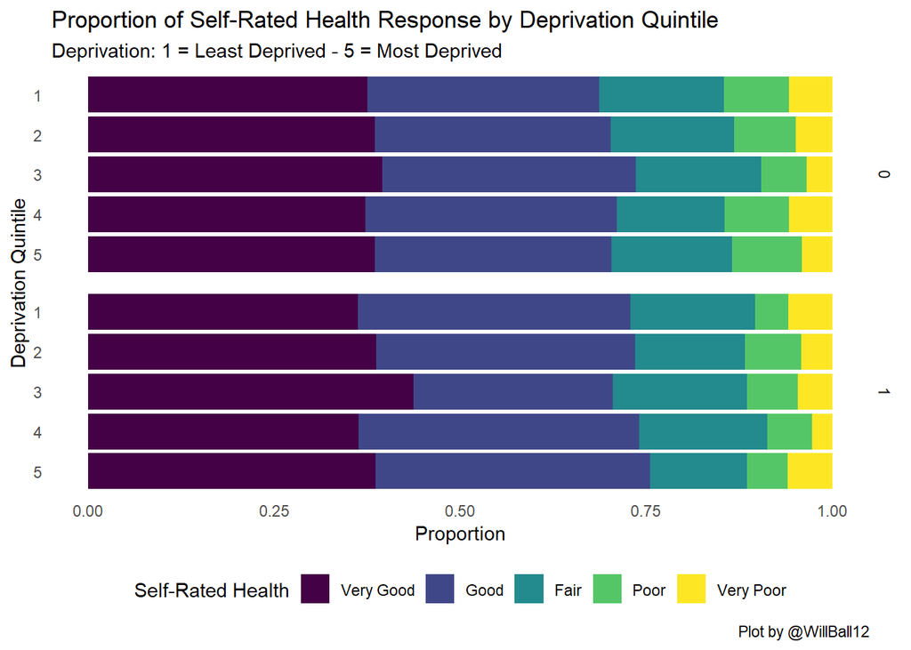

### Option 4: River/Alluvial/Sankey Plot

River plots are normally used to show ‘flow’ through a process but it’s possible to adapt them to to show how two categorical variables relate to each other.

Before we can produce the plot, it’s necessary to create a frequency table of all the variables of interest. Below you’ll see that each row is now a unique combination of the levels.

```r
mockup_freq <- mockup %>%
  dplyr::count(health, deprivation) %>%
  mutate(proptot = prop.table(n))
head(mockup_freq)
```

```
## # A tibble: 6 x 4
##   health deprivation     n proptot
##   <fct>  <fct>       <int>   <dbl>
## 1 1      1             534  0.107
## 2 1      2             438  0.0876
## 3 1      3             346  0.0692
## 4 1      4             345  0.069
## 5 1      5             249  0.0498
## 6 2      1             471  0.0942
```

Here’s how we make the riverplot itself. It uses the `geom_alluvium()` and `geom_stratum()` function which is an extension to ggplot2 from the ggalluvial package.

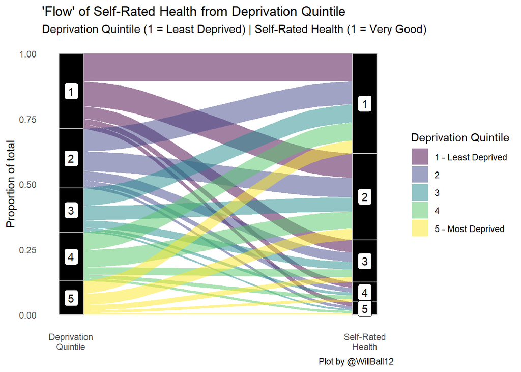

```r
ggplot(as.data.frame(mockup_freq),
       aes(y = proptot, axis1 = deprivation,
           axis2 = health)) +
  geom_alluvium(aes(fill = deprivation),
                width = 1/12) +
  geom_stratum(width = 1/12,
               fill = "black",
               colour = "grey") +
  geom_label(stat = "stratum",
             infer.label = TRUE) +
  scale_x_discrete(limits = c("deprivation", "health"),
                   expand = c(.05, .05),
                   labels = c("Deprivation\nQuintile", "Self-Rated\nHealth")) +
  ggtitle("'Flow' of Self-Rated Health from Deprivation Quintile") +
  scale_fill_manual(values=c("#440145FF", "#404788FF", "#238A8DFF", "#55C667FF", "#FDE725FF"),
                    name="Deprivation Quintile",
                    breaks=c("1", "2", "3", "4", "5"),
                    labels=c("1 - Least Deprived", "2", "3", "4", "5 - Most Deprived")) +
  theme_minimal() +
  theme(legend.position = "right",
        panel.grid.major = element_blank(),
        panel.grid.minor = element_blank()) +
  labs(y = "Proportion of total",
       subtitle = "Deprivation Quintile (1 = Least Deprived) | Self-Rated Health (1 = Very Good)",
       caption = "Plot by @WillBall12")
```

### Further Reading

That’s a quick introduction to just 4 ways that you could present this type of information. I’m sure there are many others and quite possibly some of them will be simpler and/or neater than what I have come up with.

#### ggplot2

For more information about ggplot2 in general you can’t go wrong with the ‘Data Visualisation’ and ‘Graphics for Communication’ sections from [R for Data Science](https://r4ds.had.co.nz/)

#### ggalluvial

The code for my alluvial/riverplot was adapted from [this](https://cran.r-project.org/web/packages/ggalluvial/vignettes/ggalluvial.html) tutorial produced by Jason Corey Brunson